# World Population

5/8/2022

## How change the population during time?

The primary goal of this presentation is to understand how the world population change depending on the time of observation and the country. It’s interesting to know also the speed of population changing and the amount of people in the future. These goals can be summarized in the following points:

- world population size;
- by-country population;
- population growth rate;
- future predictions on population.

## Outline

- world population today;
- population by state;
- population in the past;
- population changing rate;
- population in the future;
- sources and citations.

## How many people are there in the world today?

Here, general information about world population.

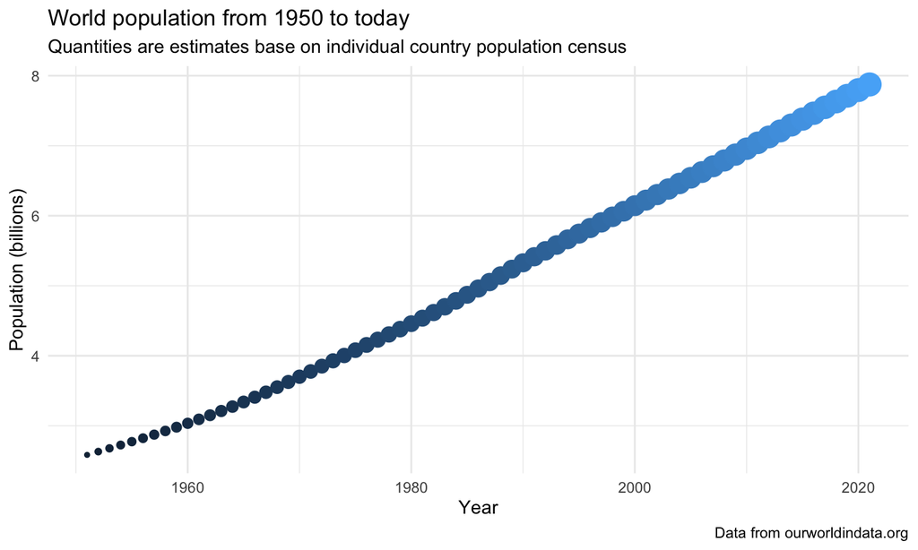

## How changed the number of people in the world in the last two centuries?

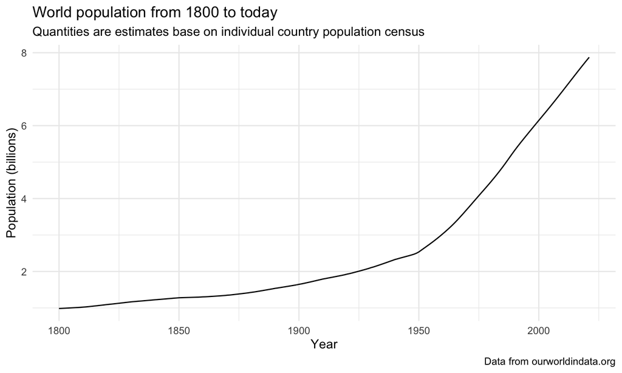

## What about individual countries?

Let’s see how changed the population in individual countries.

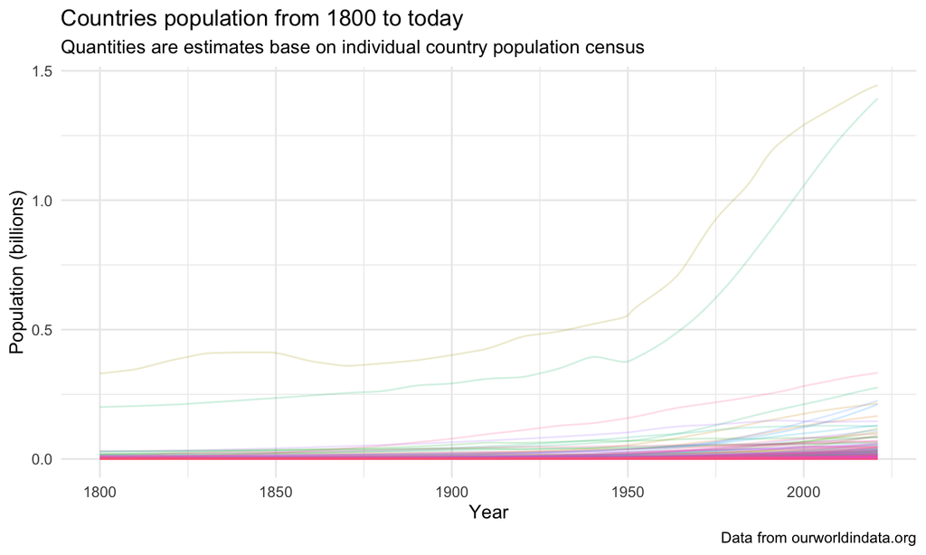

Here we can see there are two countries with more than a billion people today and have a very big margin than all the others countries. These correspond to:

- China with 1.4442161 and
- India with 1.393409 billions of people.

## What about specific countries?

Here, let’s show how population grew in individual countries like Italy.

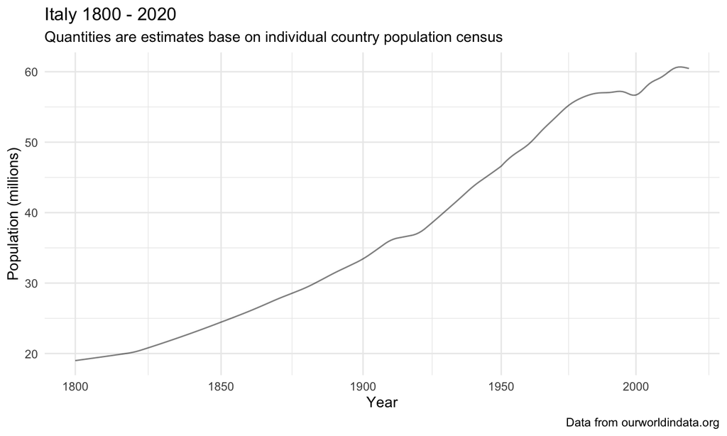

## What’s the trend starting from the antiquity?

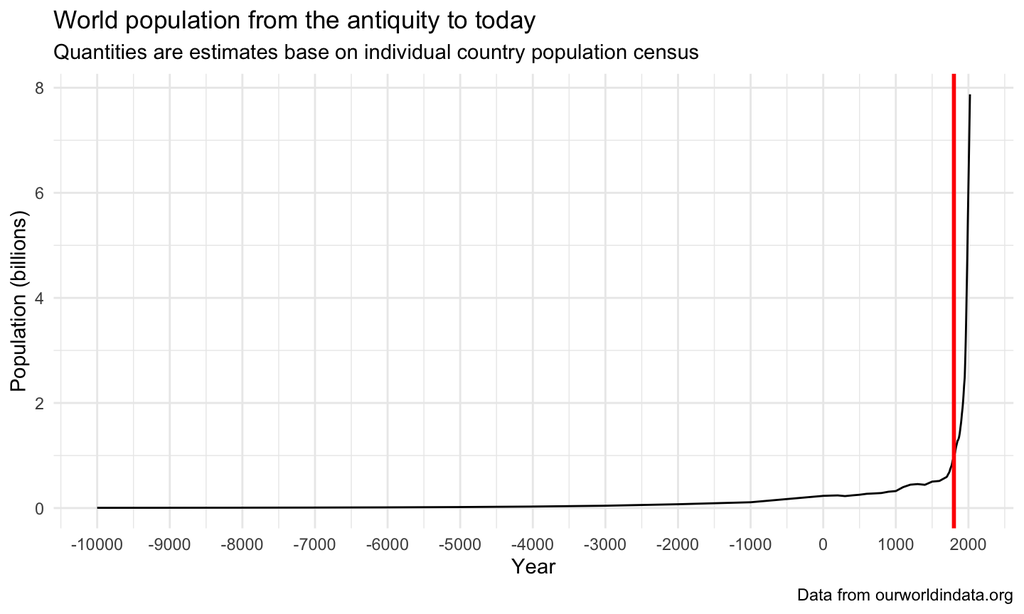

- This isn’t very informative, it only tells that thousands of years ago there were much less people than today and in the last few centuries world population grew a lot!
- The exponential population growth of the last few centuries (i.e. from about 1800) may be caused by two main events:
  - the Renaissance;
  - Industrial Revolution.

## How did population grow in individual countries?

- Let’s try to fit a model for a single country like United States.
- The objective of this and further linear models is to evidence a trend/pattern between year and population size or rate as a predictive model. If a year or period of time, data on population isn’t kept then the model can predict a value for this period of time from the data already collected.

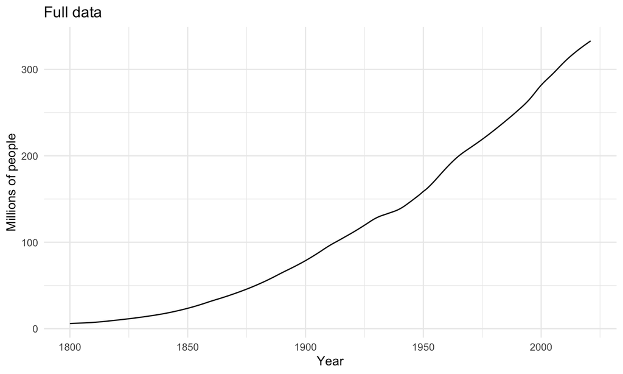

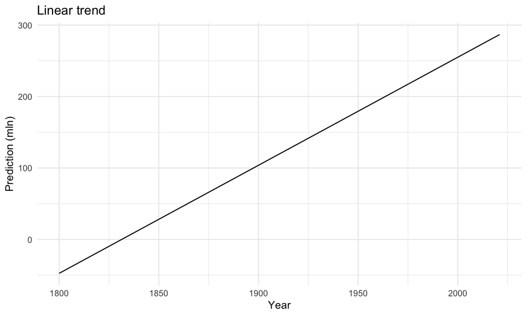

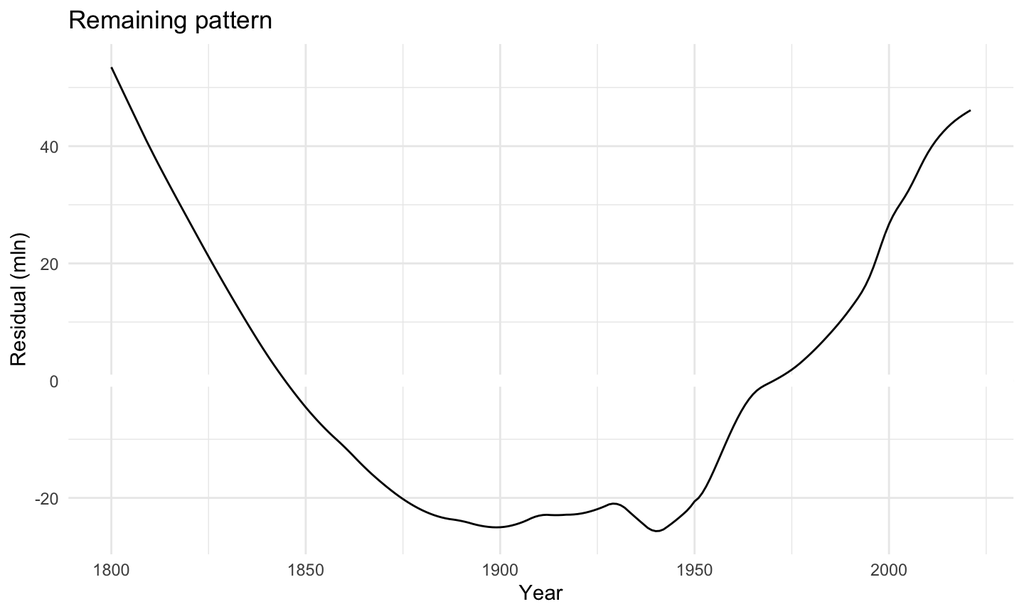

## How did population grow in individual countries?

Let’s try generate a model for a single country like Italy.

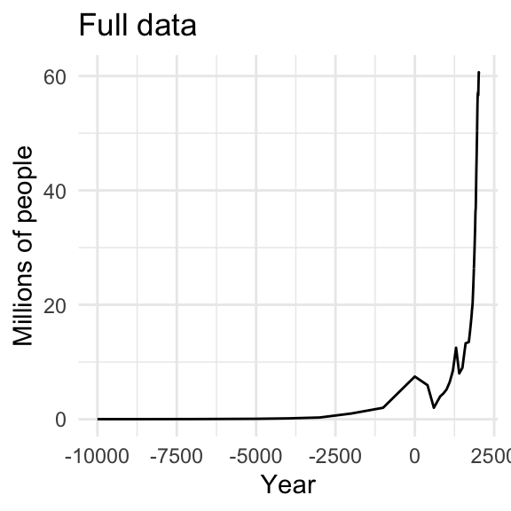

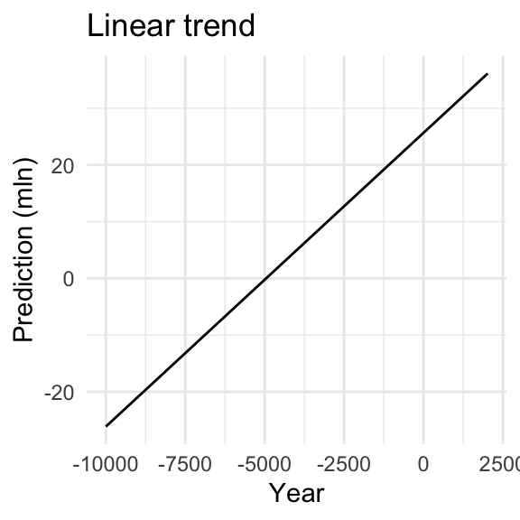

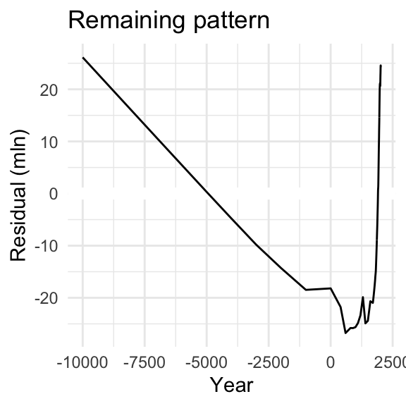

From the chart of Italy growth, it can be seen that there’s an unusual pattern between year zero and year 1750. Let’s focus on that area.

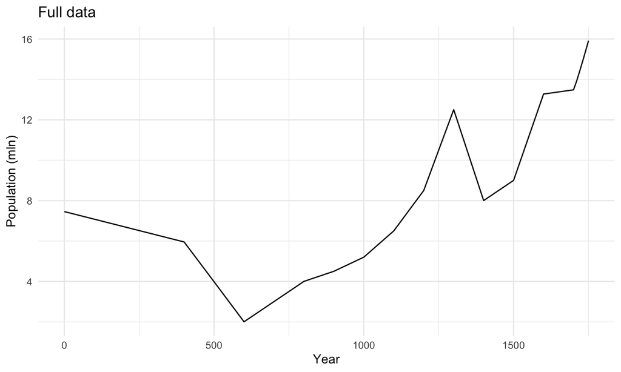

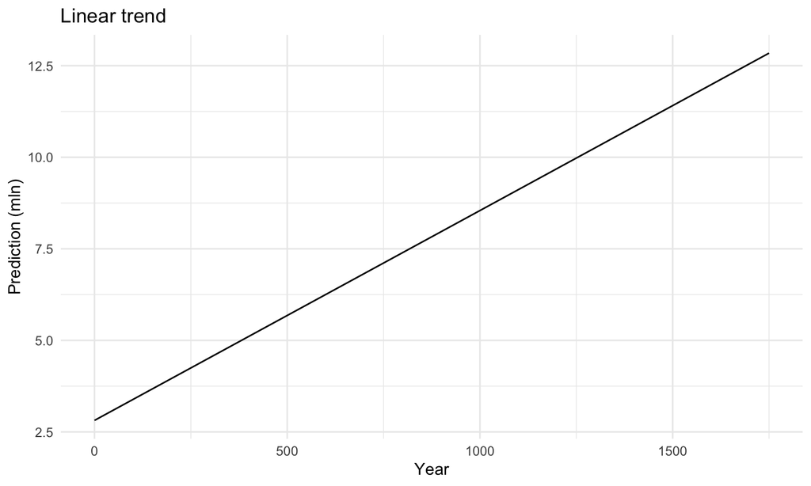

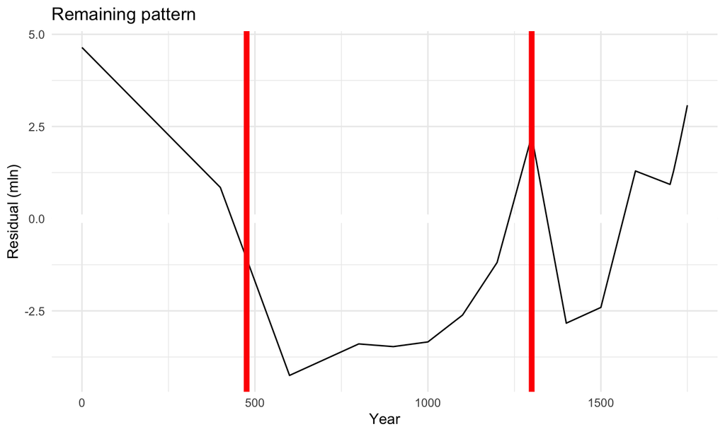

From this chart it’s clear that some reasons for this unexpected behavior are:

- the fall of Western Roman Empire in 476 A.D. and
- epidemics and famines in the Middle Ages.

## What’s the trend for each country?

Here, the objective is to compute a model for all countries and show which of these best fit and worst fit to the model.

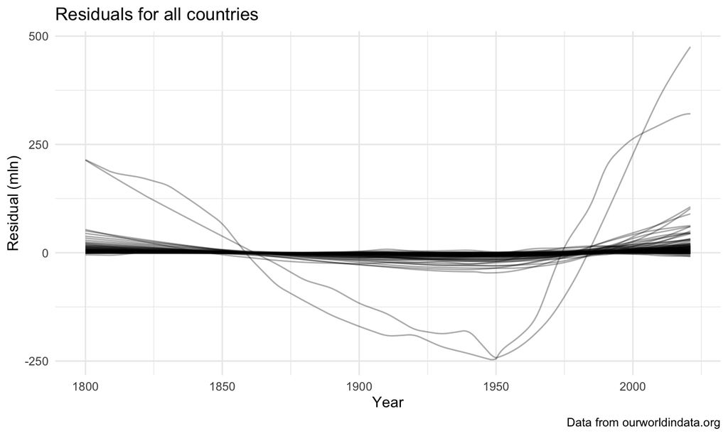

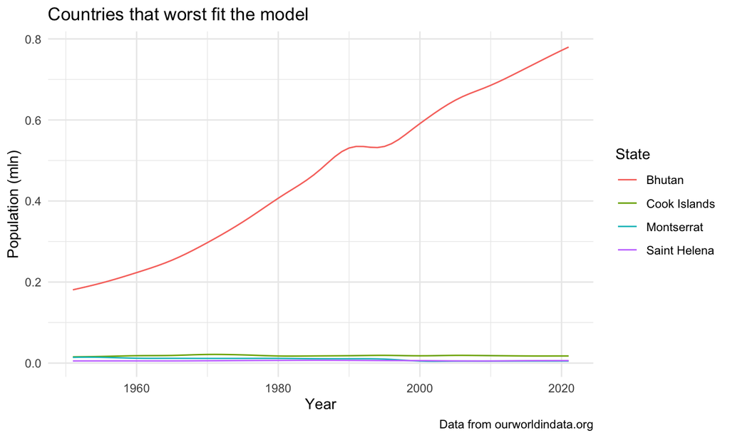

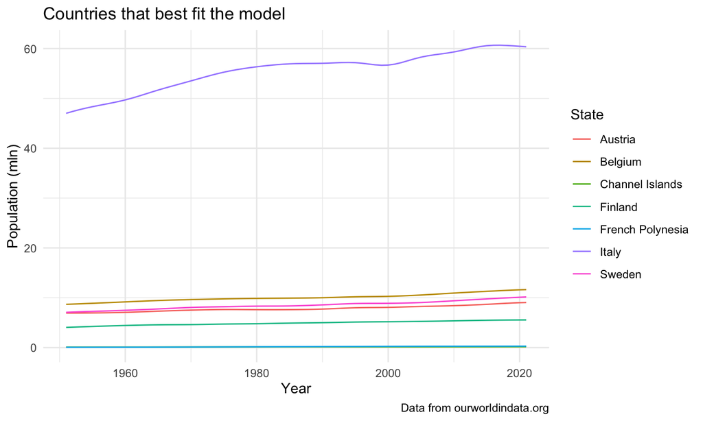

## How fast is the population growing?

Here, the purpose is to analyse the rate of population growing and its relationship with the actual number of people (population).

> Definition (annual population growth rate): The annual average rate of change of population size, for a given country, territory, or geographic area, during a specified period.

The growth rate is the percentage of the ratio between annual population increase and total population size. The increase is the sum of:

- difference between births and deaths;
- difference between immigrants and emigrants.

That is refereed to an entity, like a country, region or the entire world, in a specific period of time.

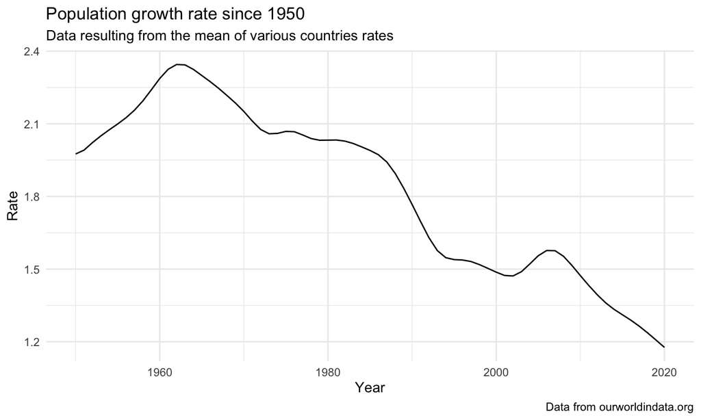

- World population reached a peak in 1962 with a growing rate of 2.344752.
- This year the world population is still growing because the mean growing rate is 1.118122.
- Population is growing slowly with respect to past decades and this can be seen from the chart where there’s the mean of rate in the last 70 years. The population over the years is growing more and more slowly because the growth rate is decreasing.

## What will happen to world population in the future?

How will change world population in the next years/decades? At what pace population will change? Will world population increase forever?

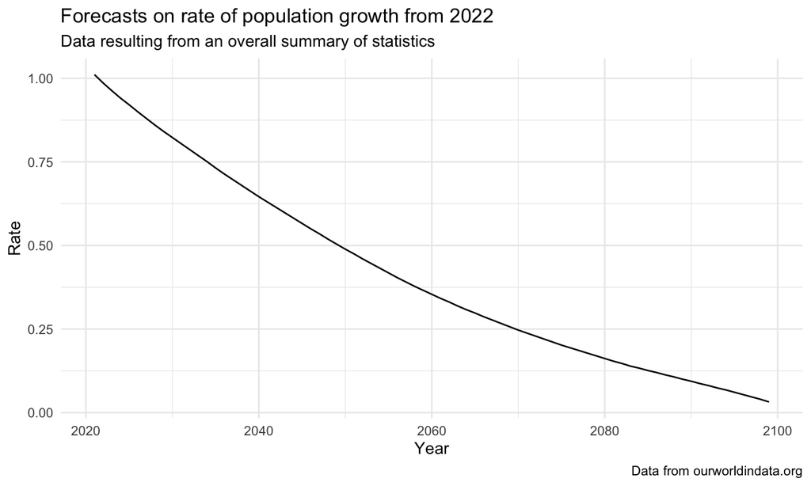

In the next years, world population growth rate will decrease, this means that population will increase in number but slowly than before. It can be seen that predictions estimate a slow decreasing of world growth rate in the next decades. This means that:

1. population is still increasing in number because the rate is positive;
2. population will grow more and more slowly because the rate is decreasing;
3. if the rate will reach zero at about year 2100, then population will remain constant in number;
4. finally, if the rate will become negative, then population will begin to decrease, inevitably.

## How will the growth rate of population change in the future?

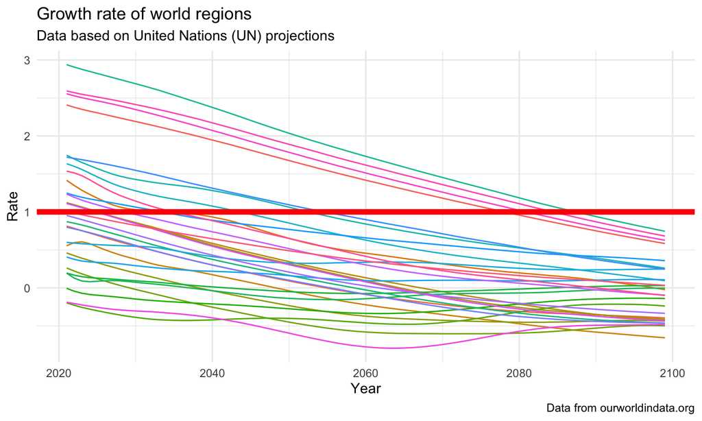

From the plot it can be seen that before 2100 all regions of the world will have a rate less than 1, this means that *no* region will increase its population faster then before.

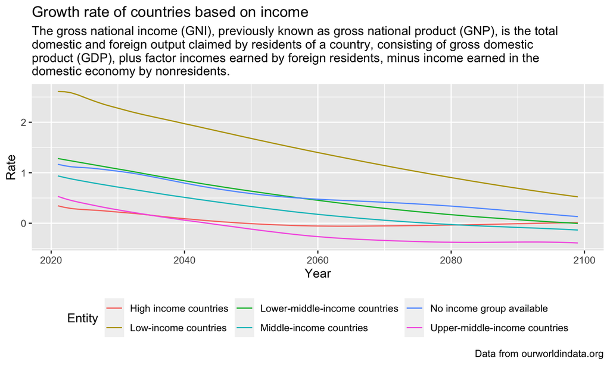

- low-income countries have a relatively high growth rate than high-income countries, in 2020.
- this difference is going to reduce with time because low-income countries will see their growth rate go down and the one of high-income countries will remain approximately the same.

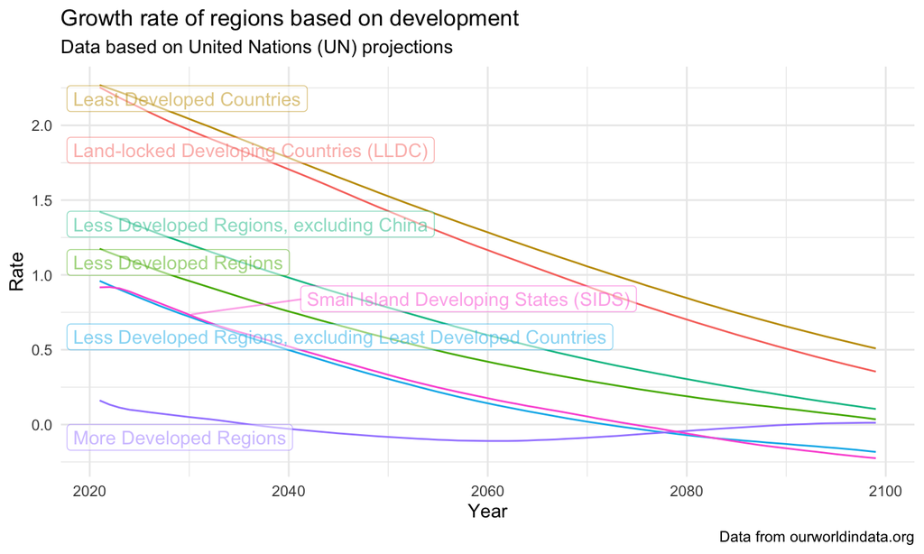

- least-developed countries start from a growth rate above two and go down to one half in the next 80 years.
- more-developed regions will remain with the same growth rate, around zero.
- note how China alone can reduce significantly the growth rate of less-developed regions. This because China has a particular control over population (e.g. China’s family planning policies). An example of such policies is *one-child policy*, an official program initiated in the late 1970s and early ’80s by the central government of China, the purpose of which was to limit the great majority of family units in the country to one child each. The rationale for implementing the policy was *to reduce the growth rate* of China’s enormous population.

## What is the pattern of world growth rate in the next 80 years?

World population growth depends on two metrics:

- number of births;
- number of deaths.

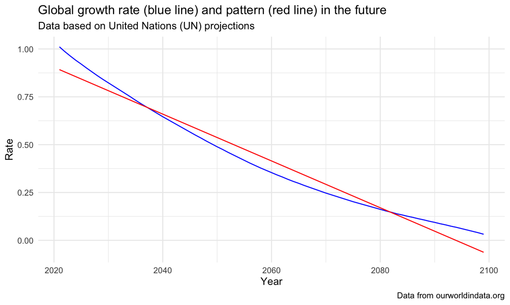

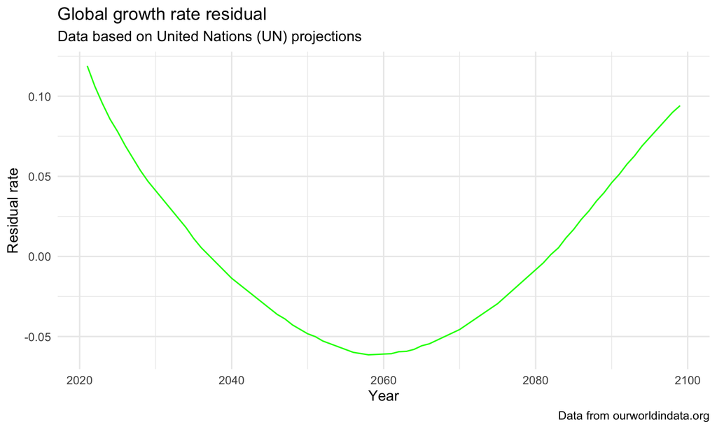

## Sources and Citations

- [Our world in data](https://ourworldindata.org/world-population-growth);
- [United Nations Population Database](http://esa.un.org/unpd/wpp/);
- Max Roser, Hannah Ritchie and Esteban Ortiz-Ospina (2013) - “World Population Growth”. Published online at OWID. Retrieved from: [Online Resource](https://ourworldindata.org/world-population-growth);
- [Wikipedia](https://en.wikipedia.org/wiki/Population_growth#Population_growth_rate);
- [World Health Organization](https://www.who.int/data/gho/indicator-metadata-registry/imr-details/1120).
- [Future population growth](https://ourworldindata.org/future-population-growth)